# Appendix 6: Example uncertainty calculation

**2.** Generate random sample pairs:

```r
n_pairs <- 1000000
sample_indices <- matrix(sample(1:dim(sampled_fields_df)[1], n_pairs * 2, replace = TRUE), ncol = 2)
```

The second line samples `n_pairs` of locations by randomly drawing row numbers within `sampled_fields_df`. `sample_indices` contains two columns, each of which represents a row in `sampled_fields_df` that defines one point in the point pair. Note that this uses pixel centers as sample locations, which means that sample locations cannot be closer together than the `ground_sample_distance`.

**3.** Compute pairwise distances:

```r
locations_u <- sampled_fields_df[sample_indices[,1],]
locations_s <- sampled_fields_df[sample_indices[,2],]
distances <- sqrt((locations_u$x - locations_s$x)^2 + (locations_u$y - locations_s$y)^2)
```

- `locations_u <- sampled_fields_df[sample_indices[,1],]` randomly samples rows from `sampled_fields_df` at the locations indicated by `sample_indices[,1]`.
- `locations_s <- sampled_fields_df[sample_indices[,2],]` randomly samples rows from `sampled_fields_df` at the locations indicated by `sample_indices[,2]`.
- `distances <- sqrt((locations_u$x - locations_s$x)^2 + (locations_u$y - locations_s$y)^2)` calculates the Euclidean distance between the two locations using their coordinates.

**4.** Compute the semivariance for each point pair using the spherical variogram:

```r
gamma <- sph_variogram(distances, psill=vgm_model_sph[2,2], range=vgm_model_sph[2,3], nugget=vgm_model_sph[1,2])
```

`sph_variogram` and `exp_variogram` are custom functions, defined above, to compute the semivariance under a spherical or exponential variogram model. `gamma` is the predicted semivariance for each pair of locations using the spherical variogram model.

**5.** Calculate the correlation function of the standardized prediction error:

```r
rho <- (sum(vgm_model_sph[,2]) - gamma) / sum(vgm_model_sph[,2])
```

The variable `rho` is the correlation function, described in step 4 of section 4 of [Wadoux and Heuvelink (2023)](https://doi.org/10.1111/2041-210X.14106) and in Equation 10 of the main text of the tool.

**7.** Compute the variance of spatial average:

```r
vars <- sampled_fields_df$sigma[sample_indices[,1]] * sampled_fields_df$sigma[sample_indices[,2]] * rho
mean(vars)
```

- `sampled_fields_df$sigma[sample_indices[,1]]` selects the predictive standard deviation value corresponding to the first point in each sample pair.
- `sampled_fields_df$sigma[sample_indices[,2]]` selects the predictive standard deviation value corresponding to the second point in each sample pair.
- `rho` multiplies these predictive standard deviation values by the spatial correlation function. `rho` is described in step 6 above, in part 4 of section 4 of [Wadoux and Heuvelink (2023)](https://doi.org/10.1111/2041-210X.14106) and in Equation 10 in the main text of the tool.
- The resulting quantity represents the variance of the mean SOC stock, which is 0.0076 at the project level. This value is smaller at the project level in comparison to any individual field. For instance, the variance of the mean for the field visualized in Figure 1 is 0.514, while the variance across all 100 fields ranges from 0.291 to 2.317. The variance diminishes at the project level because most locations are farther apart than the variogram range, resulting in an effective correlation of nearly zero in many cases.

**VI. Variance of the mean stock change and computing the uncertainty deduction**

As described in the main text of the tool, the variance of the mean stock change is:

$\textit{var}\left(\overline{\widehat{\textit{SOC}}}_{t,\Delta t}\right) = \textit{var}\left(\overline{\widehat{\textit{SOC}}}_{t+\Delta t}\right) + \textit{var}\left(\overline{\widehat{\textit{SOC}}}_{t}\right) - 2 \rho \cdot \sqrt{{var}\left(\overline{\widehat{\textit{SOC}}}_{t+\Delta t}\right)} \cdot \sqrt{{var}\left(\overline{\widehat{\textit{SOC}}}_{t}\right)}$  
(Equation 5 in the main text)

Here we illustrate how to use estimates of the variance of the mean to compute the uncertainty deduction under [VM0042 version 2.1](https://verra.org/methodologies/vm0042-improved-agricultural-land-management-v2-1/). The variance computed in section V corresponds to the term:

$\textit{var}\left(\overline{\widehat{\textit{SOC}}}_{t}\right)$ = 0.0076 (in Equations 5 and 12 of the main text)

Assume that this procedure is repeated at a second point in time three years later, and the estimate is one third larger:

$\textit{var}\left(\overline{\widehat{\textit{SOC}}}_{t,\Delta t}\right)$ = 0.0101 (in Equations 5 and 7 of the main text)

Using Equation 5 in the main text, the variance of the mean stock change is $0.0076 + 0.0101 - 0.0044 = 0.0133$. Note that the covariance term is subtracted and can be conservatively ignored because it is very unlikely to increase the estimate of the variance of the mean stock change.

To illustrate how the uncertainty deduction would be calculated, we will assume that the project is monitored for three years and experiences a moderate annual sequestration rate equal to 0.2 tons of SOC / hectare / year. The rate over three years is simply three times the annual rate, or $0.2 \times 3 = 0.6$.

We will also assume that the annual sequestration rate in the baseline control area is 0. Thus, in the absence of any uncertainty, the potentially creditable amount of sequestration over three years is the nominal value of 0.6 minus the baseline control value, or an increase from 54 to 54.6 tons of SOC / hectare, given that this simulation assumed a starting value of 54 tons of SOC / hectare. We further assume that the variance of the mean stock change in the baseline control area is equivalent to the project variance of $0.0133$.

Using Equation 6 in the main text of the tool, the mean emissions removal estimate in soil is:

$$\text{CO2}_{\text{soil},\ t,\ \Delta t} = \overline{\widehat{\Delta \text{SOC}}}_{t,\ \Delta t} - \overline{\widehat{\Delta \text{SOC}}}_{\text{bsl},\ t,\ \Delta t} \times \frac{44}{12}$$
This corresponds to $0.6 - 0 \times \frac{44}{12} = 2.2$ in units of CO2e. The variance of the mean emissions removal estimate is calculated using Equation 7 in the main text. Here this value is $0.0133 + 0.0133 \times \frac{44}{12} = 0.0979$ in units of CO2e.

The figure below shows the probability distribution of the mean SOC change in units of CO2e, and is similar to Figure 4 on page 85 of [VM0042 version 2.1](https://verra.org/methodologies/vm0042-improved-agricultural-land-management-v2-1/). Using the standard deviation of the mean emissions removal estimate (i.e. $\sqrt{0.0979} = 0.3128$, the probability of exceedance method results in a creditable amount of of 0.5632 tons of SOC / hectare, or a 6.1% deduction relative to the nominal value. If we decrease the monitoring period to 2 years or 1, resulting in a nominal sequestration rate of 0.4 or 0.2 tons of SOC / hectare / year, respectively, the probability of exceedance method indicates creditable amounts of 0.3632 and 0.1632 tons of SOC / hectare, or deductions of 9.2% and 18.4% relative to the nominal value in each case.

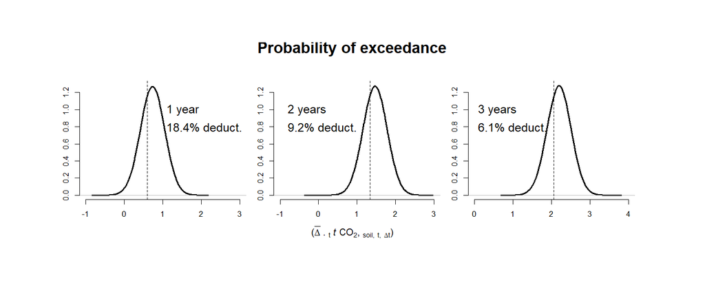

**Figure 1:** Probability of exceedance. The value for $\bar{\Delta}{\:\cdot_{\:t}}{(t \: \text{CO2}_{\text{soil},\ t,\ \Delta t})}$ used in the calculation of VCUs issued is determined by applying an uncertainty deduction based on the 33.3rd percentile of the estimated probability distribution of $\bar{\Delta}{\:\cdot_{\:t}}{(t \: \text{CO2}_{\text{soil},\ t,\ \Delta t})}$. This variance of the probability distribution is estimated using the methods described in this document.